# SIG17 CRISPR screen — UMI clone representation (Gata3 arm)

EYW

2026-08-12

```r
library(tidyverse)
library(patchwork)
library(ggrepel)
library(RColorBrewer)
library(scales)
library(jsonlite)
knitr::opts_chunk$set(echo = TRUE, message = FALSE, warning = FALSE)
```

```r
source("../../functions/r_custom/plotting_fxns.R")
theme_set(theme_Publication())
```

# Goal

Quantify how many **UMI clones** (independent transduced cells) support each gene in each sorted bin of the Gata3 arm of the SIG17 screen (TGFb + TNF condition, samples `SIG17_1-4`; bin 1 = lowest GATA3-reporter, bin 4 = highest).

Sequencing is saturated in this experiment — every bin has a duplication rate of ~99%, i.e. each original molecule was resequenced ~100x on average (confirmed in the last section). A UMI cluster count is therefore an **absolute count of cells carrying that sgRNA**, not a subsample of them.

# Import

```r
pipe_dir  <- "/data1/rudenska/EYW/SIG17_redo/dedup_pipeline/output"
dedup_dir <- file.path(pipe_dir, "02_guide_dedup")

# Gata3 arm: SIG17_1-4 == GATA3-reporter bins 1-4 (low -> high)
bin_samples <- c(`1` = "SIG17_1", `2` = "SIG17_2",
                 `3` = "SIG17_3", `4` = "SIG17_4")

# per-sgRNA UMI QC emitted by dedup_pipeline/02_guide_dedup.py
sg <- imap_dfr(bin_samples, function(s, b) {
  read_tsv(file.path(dedup_dir, paste0(s, ".umi_per_guide.tsv")),
           show_col_types = FALSE) %>%
    mutate(sample = s, bin = as.integer(b))
}) %>%
  mutate(
    # controls have 47 guides each vs 4 for a targeting gene, so they are never
    # pooled into gene-level sums -- they are carried as their own series.
    category = case_when(
      gene == "control_NT"      ~ "control_NT",
      gene == "control_cutting" ~ "control_cutting",
      TRUE                      ~ "targeting"
    ),
    bin_lab = factor(paste("bin", bin), levels = paste("bin", 1:4))
  )

# per-sample dedup summary + clone-size histogram
stats_raw <- map(bin_samples, ~ fromJSON(file.path(dedup_dir, paste0(.x, ".dedup_stats.json"))))

bin_stats <- imap_dfr(stats_raw, function(d, b) {
  tibble(
    bin               = as.integer(b),
    total_reads       = d$total_reads,
    guide_matched     = d$guide_matched,
    umi_clusters      = d$total_umi_clusters,
    unique_umis_raw   = d$total_unique_umis_raw,
    duplication_rate  = d$duplication_rate,
    clone_size_mean   = d$clone_size_mean,
    clone_size_median = d$clone_size_median,
    singletons        = d$clone_size_singletons,
    guides_detected   = d$unique_guides_detected
  )
}) %>%
  mutate(bin_lab = factor(paste("bin", bin), levels = paste("bin", 1:4)))

bin_stats
```

```
## # A tibble: 4 × 11
##     bin total_reads guide_matched umi_clusters unique_umis_raw duplication_rate
##   <int>       <int>         <int>        <int>           <int>            <dbl>
## 1     1    25879002      25524686       206126          350944            0.992
## 2     2    22914733      22569143       201114          336004            0.991
## 3     3    28605897      28183935       325342          482790            0.988
## 4     4    25919540      25541299       175506          307922            0.993
## # ℹ 5 more variables: clone_size_mean <dbl>, clone_size_median <int>,
## #   singletons <int>, guides_detected <int>, bin_lab <fct>
```

# Mean UMI clones per gene across bins

Left panel is on the **per-sgRNA** scale so targeting genes and the two control guide sets are directly comparable — the control lines are the reference for how many cells a non-perturbing guide puts in each bin, so the bin-to-bin shape of the targeting mean should be read against the control shape. Right panel is the per-gene total (sum of 4 sgRNAs), the quantity that sets statistical power for a gene-level test in that bin.

```r
# gene-level clone counts: sum over a gene's sgRNAs (targeting genes only)
gene_clones <- sg %>%
  filter(category == "targeting") %>%
  group_by(gene, bin, bin_lab) %>%
  summarise(clones       = sum(umi_clusters),
            clones_per_sg = mean(umi_clusters),
            n_sg          = n(),
            .groups = "drop")

# control sgRNA sets, kept on the per-sgRNA scale
control_clones <- sg %>%
  filter(category != "targeting") %>%
  select(series = category, sgRNA_id, bin, bin_lab, clones_per_sg = umi_clusters)
```

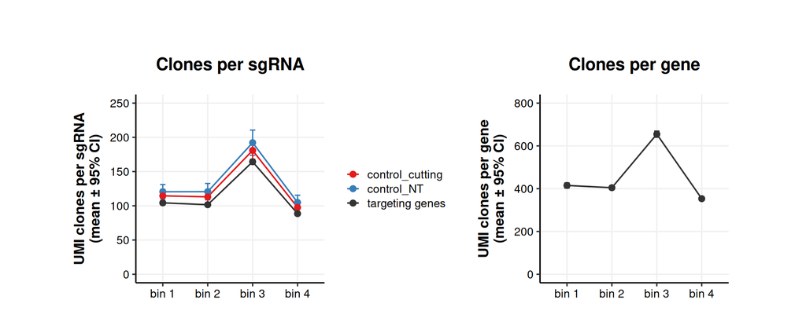

```r
mean_ci <- function(x) {
  n <- sum(!is.na(x)); m <- mean(x, na.rm = TRUE)
  se <- sd(x, na.rm = TRUE) / sqrt(n)
  tibble(mean = m, lo = m - 1.96 * se, hi = m + 1.96 * se, n = n)
}

# combined per-sgRNA-scale series
per_sg_series <- bind_rows(
  gene_clones %>% transmute(series = "targeting genes", bin, bin_lab, clones_per_sg),
  control_clones %>% transmute(series, bin, bin_lab, clones_per_sg)
)

per_sg_summ <- per_sg_series %>%
  group_by(series, bin, bin_lab) %>%
  reframe(mean_ci(clones_per_sg))

series_cols <- c("targeting genes" = "grey20",
                 "control_cutting" = "#E41A1C",
                 "control_NT"      = "#377EB8")

p1a <- ggplot(per_sg_summ, aes(bin_lab, mean, colour = series, group = series)) +
  geom_line(linewidth = 0.7) +
  geom_errorbar(aes(ymin = lo, ymax = hi), width = 0.12, linewidth = 0.6) +
  geom_point(size = 2.4) +
  scale_colour_manual(values = series_cols) +
  ylim(0,250) +
  labs(x = NULL, y = "UMI clones per sgRNA\n(mean ± 95% CI)",
       title = "Clones per sgRNA", colour = NULL) +
  theme(aspect.ratio = 1)

gene_summ <- gene_clones %>%
  group_by(bin, bin_lab) %>%
  reframe(mean_ci(clones))

p1b <- ggplot(gene_summ, aes(bin_lab, mean, group = 1)) +
  geom_line(linewidth = 0.7, colour = "grey20") +
  geom_errorbar(aes(ymin = lo, ymax = hi), width = 0.12, linewidth = 0.6,
                colour = "grey20") +
  geom_point(size = 2.4, colour = "grey20") +
  ylim(0,800) +
  labs(x = NULL, y = "UMI clones per gene\n(mean ± 95% CI)",
       title = "Clones per gene") +
  theme(aspect.ratio = 1)

p1a + p1b
```

```r
ggsave("../../analysis_outs/SIG17_tgfb_tnf/clone_mean_per_bin.pdf")
```

# Clone distribution per gene, per bin

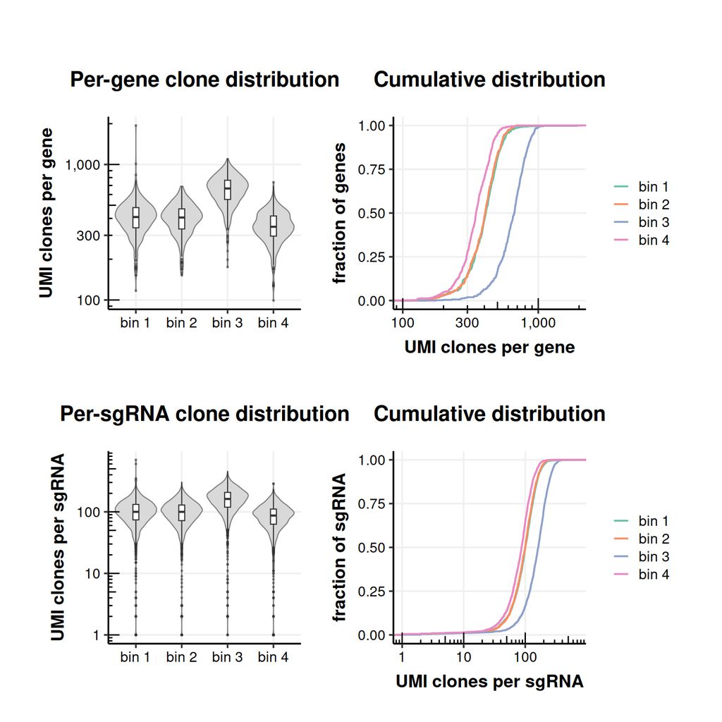

```r
p2a <- ggplot(gene_clones, aes(bin_lab, clones)) +
  geom_violin(fill = "grey85", colour = "grey50", scale = "width",
              linewidth = 0.4) +
  geom_boxplot(width = 0.13, outlier.size = 0.4, outlier.alpha = 0.4,
               linewidth = 0.4) +
  scale_y_log10(labels = comma) +
  annotation_logticks(sides = "l") +
  labs(x = NULL, y = "UMI clones per gene",
       title = "Per-gene clone distribution") +
  theme(aspect.ratio = 1)

p2b <- ggplot(gene_clones, aes(clones, colour = bin_lab)) +
  stat_ecdf(linewidth = 0.7) +
  scale_x_log10(labels = comma) +
  annotation_logticks(sides = "b") +
  scale_colour_brewer(palette = "Set2") +
  labs(x = "UMI clones per gene", y = "fraction of genes",
       colour = NULL, title = "Cumulative distribution") +
  theme(aspect.ratio = 1)

p2c <- ggplot(sg, aes(bin_lab, umi_clusters)) +
  geom_violin(fill = "grey85", colour = "grey50", scale = "width",
              linewidth = 0.4) +
  geom_boxplot(width = 0.13, outlier.size = 0.4, outlier.alpha = 0.4,
               linewidth = 0.4) +
  scale_y_log10(labels = comma) +
  annotation_logticks(sides = "l") +
  labs(x = NULL, y = "UMI clones per sgRNA",
       title = "Per-sgRNA clone distribution") +
  theme(aspect.ratio = 1)

p2d <- ggplot(sg, aes(umi_clusters, colour = bin_lab)) +
  stat_ecdf(linewidth = 0.7) +
  scale_x_log10(labels = comma) +
  annotation_logticks(sides = "b") +
  scale_colour_brewer(palette = "Set2") +
  labs(x = "UMI clones per sgRNA", y = "fraction of sgRNA",
       colour = NULL, title = "Cumulative distribution") +
  theme(aspect.ratio = 1)

p2a + p2b + p2c + p2d + plot_layout(ncol = 2)
```

```r
ggsave("../../analysis_outs/SIG17_tgfb_tnf/clone_distribution_per_bin.pdf")
```

# Assumption check: is sequencing saturated?

The informative quantity is **reads per clone**: if even the most abundant sgRNAs are resequenced many times per molecule, no clone is being missed for want of reads.

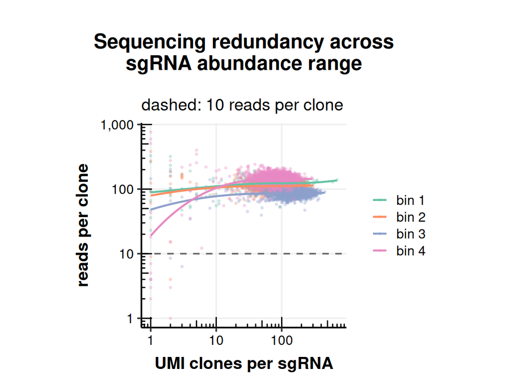

```r
sat <- sg %>%
  filter(umi_clusters > 0, reads_matched > 0) %>%
  mutate(reads_per_clone = reads_matched / umi_clusters)

p4 <- ggplot(sat, aes(umi_clusters, reads_per_clone, colour = bin_lab)) +
  geom_point(size = 0.5, alpha = 0.25) +
  geom_smooth(method = "loess", se = FALSE, linewidth = 0.8) +
  geom_hline(yintercept = 10, linetype = "dashed", colour = "grey40") +
  scale_x_log10(labels = comma) +
  scale_y_log10(labels = comma) +
  annotation_logticks() +
  scale_colour_brewer(palette = "Set2") +
  labs(x = "UMI clones per sgRNA", y = "reads per clone",
       colour = NULL,
       title = "Sequencing redundancy across\nsgRNA abundance range",
       subtitle = "dashed: 10 reads per clone") +
  theme(aspect.ratio = 1)

p4
```

```r
ggsave("../../analysis_outs/SIG17_tgfb_tnf/clone_sequencing_saturation.pdf")
```

```r
n_lib_guides <- nrow(read_csv(file.path(dirname(pipe_dir), "mageck_library.csv"),
                              col_names = c("sgRNA_id", "sequence", "gene"),
                              show_col_types = FALSE))

bin_stats %>%
  transmute(
    bin_lab,
    reads_per_clone = round(guide_matched / umi_clusters, 1),
    duplication_rate = percent(duplication_rate, accuracy = 0.01),
    clone_size_median,
    guides_detected,
    guides_missing = n_lib_guides - guides_detected
  )
```

```
## # A tibble: 4 × 6
##   bin_lab reads_per_clone duplication_rate clone_size_median guides_detected
##   <fct>             <dbl> <chr>                        <int>           <int>
## 1 bin 1             124.  99.19%                          72            1965
## 2 bin 2             112.  99.11%                          46            1965
## 3 bin 3              86.6 98.85%                           9            1966
## 4 bin 4             146.  99.31%                          15            1968
## # ℹ 1 more variable: guides_missing <int>
```

# Summary

```r
gene_clones %>%
  group_by(bin_lab) %>%
  summarise(mean_clones_per_gene = round(mean(clones)),
            median_clones_per_gene = median(clones),
            min_clones_per_gene = min(clones), .groups = "drop") %>%
  left_join(
    control_clones %>%
      group_by(bin_lab) %>%
      summarise(median_control_per_sg = median(clones_per_sg), .groups = "drop"),
    by = "bin_lab") %>%
  left_join(select(bin_stats, bin_lab, total_clones = umi_clusters,
                   reads_per_clone = clone_size_mean) %>%
              mutate(reads_per_clone = round(reads_per_clone)),
            by = "bin_lab")
```

```
## # A tibble: 4 × 7
##   bin_lab mean_clones_per_gene median_clones_per_gene min_clones_per_gene
##   <fct>                  <dbl>                  <dbl>               <dbl>
## 1 bin 1                    415                   410.                 117
## 2 bin 2                    405                   406                  152
## 3 bin 3                    655                   665                  175
## 4 bin 4                    353                   347                   99
## # ℹ 3 more variables: median_control_per_sg <dbl>, total_clones <int>,
## #   reads_per_clone <dbl>
```